# Statistics Module - Day 1

# CMM262: Statistics, Day 1 - Part 1 - Visualizing Data, Summary Statistics, and Distributions

**Credits**: Based on a prior notebook developed by former TAs Michelle Franc Ragsac (mragsac@eng.ucsd.edu) and Clarence Mah (ckmah@ucsd.edu) .

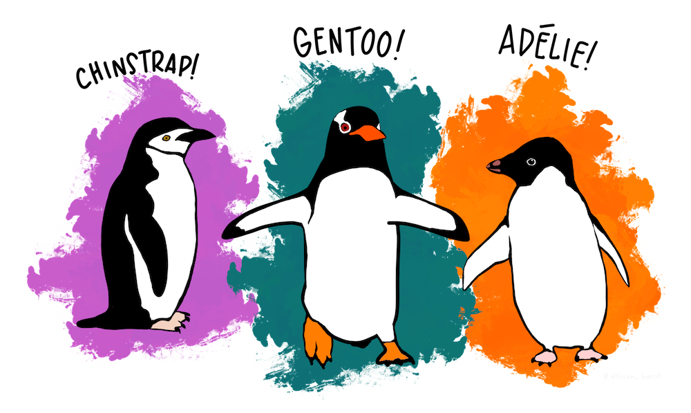

Image of the Chinstrap, Gentoo, and Adélie penguins from the Palmer Penguins dataset

### Exercise 1 - Visualizing Data

> The Palmer Penguins dataset is based on data points collected and made available by [Dr. Kristen Gorman](https://www.uaf.edu/cfos/people/faculty/detail/kristen-gorman.php) and the [Palmer Station, Antarctica LTER](https://pal.lternet.edu/), a member of the [Long Term Ecological Research Network](https://lternet.edu/).

> Source: https://allisonhorst.github.io/palmerpenguins/

```r
# install the Palmer Penguins dataset
install.packages("palmerpenguins", repos="https://cloud.r-project.org")
install.packages("ggridges", repos="https://cloud.r-project.org")
```

Let’s import the Palmer penguins library and load the penguins dataset

```r
library(palmerpenguins)
data(penguins, package='palmerpenguins')
```

The penguins dataset is in a [tibble](https://www.rstudio.com/blog/tibble-1-0-0/) which is a more user-friendly version of a data frame. We can view the data in the table:

```r
head(penguins, 20)
```

| species | island | bill_length_mm | bill_depth_mm | flipper_length_mm | body_mass_g | sex | year |
| --- | --- | --- | --- | --- | --- | --- | --- |
| Adelie | Torgersen | 39.1 | 18.7 | 181 | 3750 | male | 2007 |
| Adelie | Torgersen | 39.5 | 17.4 | 186 | 3800 | female | 2007 |
| Adelie | Torgersen | 40.3 | 18.0 | 195 | 3250 | female | 2007 |
| Adelie | Torgersen | NA | NA | NA | NA | NA | 2007 |
| Adelie | Torgersen | 36.7 | 19.3 | 193 | 3450 | female | 2007 |
| Adelie | Torgersen | 39.3 | 20.6 | 190 | 3650 | male | 2007 |
| Adelie | Torgersen | 38.9 | 17.8 | 181 | 3625 | female | 2007 |
| Adelie | Torgersen | 39.2 | 19.6 | 195 | 4675 | male | 2007 |
| Adelie | Torgersen | 34.1 | 18.1 | 193 | 3475 | NA | 2007 |
| Adelie | Torgersen | 42.0 | 20.2 | 190 | 4250 | NA | 2007 |

[output cut: 10 more lines]

We can get a quick summary of the whole dataset using ‘summary’:

```r
summary(penguins)
```

```
##       species          island    bill_length_mm  bill_depth_mm
##  Adelie   :152   Biscoe   :168   Min.   :32.10   Min.   :13.10
##  Chinstrap: 68   Dream    :124   1st Qu.:39.23   1st Qu.:15.60
##  Gentoo   :124   Torgersen: 52   Median :44.45   Median :17.30
##                                  Mean   :43.92   Mean   :17.15
##                                  3rd Qu.:48.50   3rd Qu.:18.70
##                                  Max.   :59.60   Max.   :21.50
##                                  NA's   :2       NA's   :2
##  flipper_length_mm  body_mass_g       sex           year
##  Min.   :172.0     Min.   :2700   female:165   Min.   :2007
##  1st Qu.:190.0     1st Qu.:3550   male  :168   1st Qu.:2007
##  Median :197.0     Median :4050   NA's  : 11   Median :2008
##  Mean   :200.9     Mean   :4202                Mean   :2008
##  3rd Qu.:213.0     3rd Qu.:4750                3rd Qu.:2009
##  Max.   :231.0     Max.   :6300                Max.   :2009
##  NA's   :2         NA's   :2
```

When working with data, it is really important to visualize it. This provides you with a much better understanding of the data than simply computing a few statistics.

The simplest way to make a histogram is with the hist function.

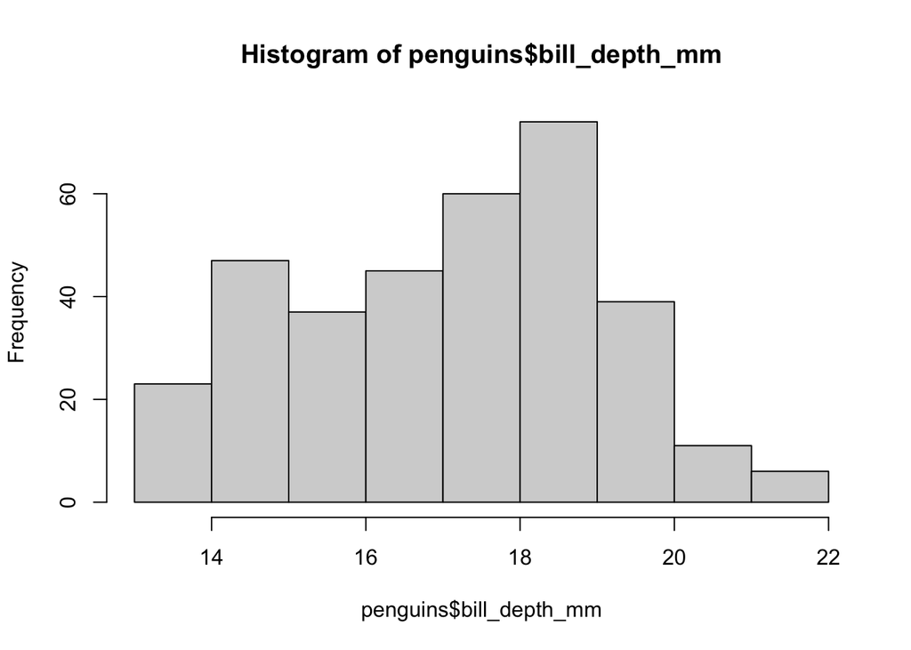

```r
hist(penguins$bill_depth_mm)
```

We can use the breaks parameter to control the binning:

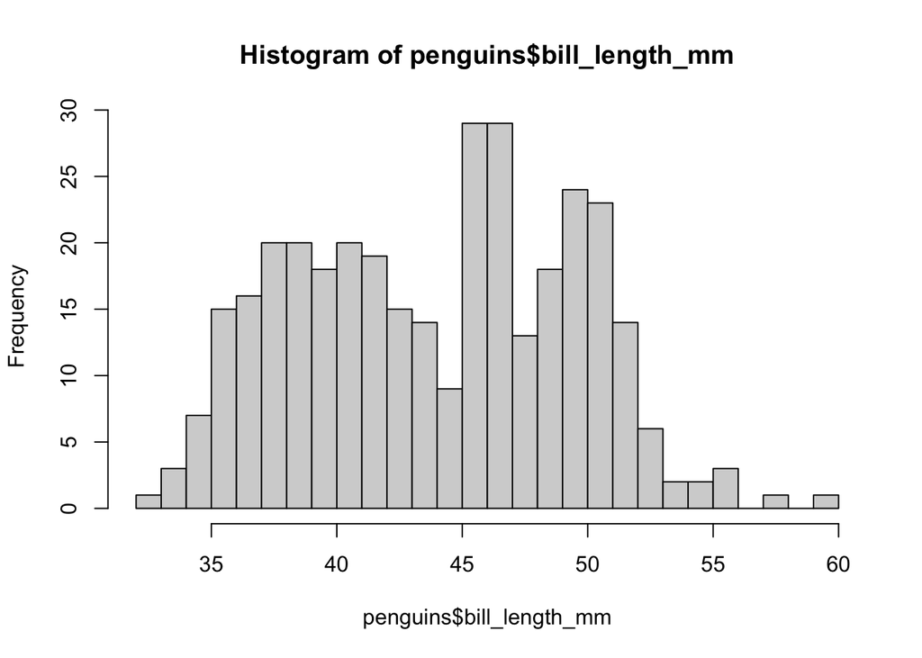

```r
hist(penguins$bill_length_mm, breaks=30)
```

[ggplot2](https://ggplot2.tidyverse.org/index.html) provides more powerful methods for plotting. ggplots syntax can take some getting used to. I recommend using a [ggplot2 cheatsheet](https://www.maths.usyd.edu.au/u/UG/SM/STAT3022/r/current/Misc/data-visualization-2.1.pdf) for reference.

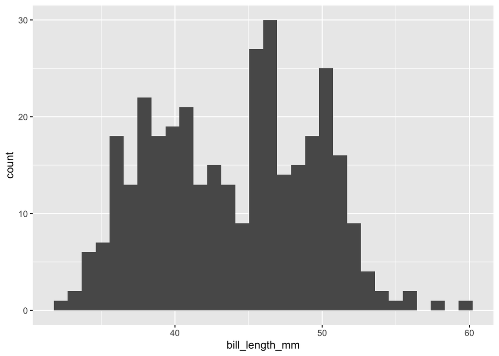

```r
library(ggplot2)
ggplot(data=penguins, aes(bill_length_mm)) + geom_histogram()
```

Notice that the distribution looks bimodal. And remember we have 3 different species of penguin in our dataset. Let’s see if the bill length differs by species. Let’s make separate overlapping histograms in different colors for each species.

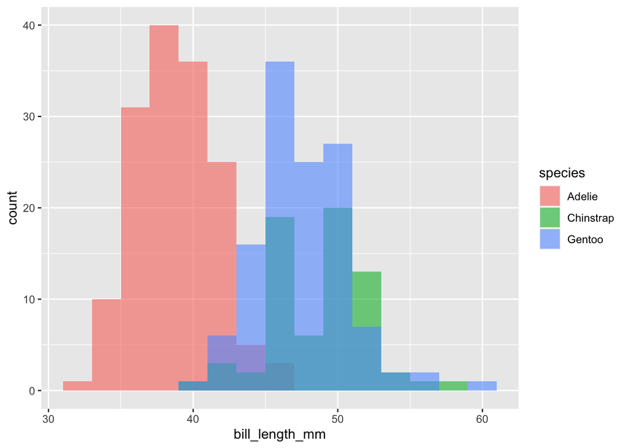

```r
ggplot(penguins, aes(x=bill_length_mm, fill=species)) + geom_histogram(position="identity", alpha=0.6, binwidth=2)
```

We can also visualize the distributions of the species as separate plots, using one of ggplot’s faceting functions.

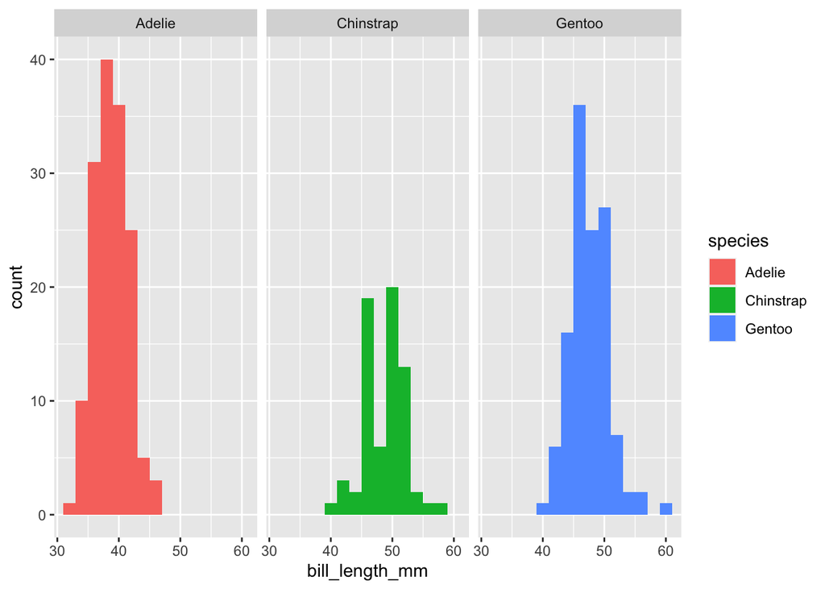

```r
ggplot(penguins, aes(x=bill_length_mm, fill=species)) + geom_histogram(binwidth=2) + facet_wrap(.~species)
```

If we want a more compact display, we can use boxplots or violin plots

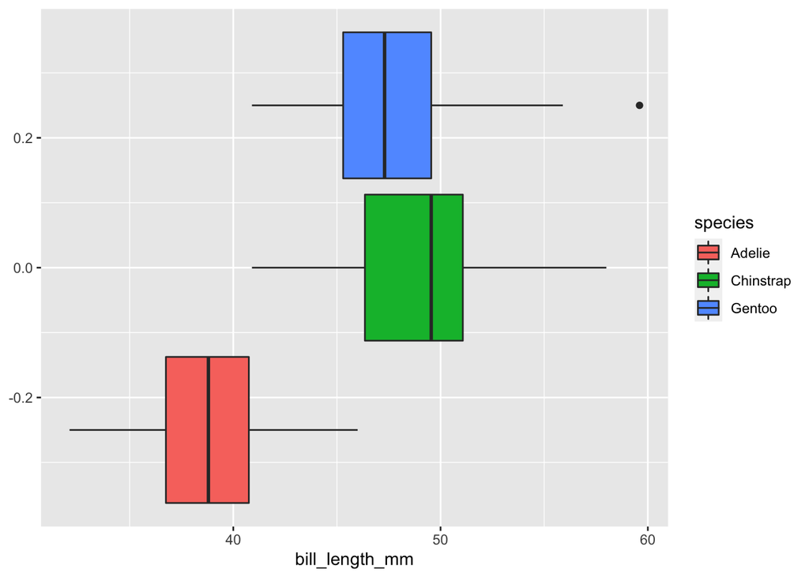

```r
ggplot(penguins, aes(x=bill_length_mm, fill=species)) + geom_boxplot()
```

ggridges is a cool package that lets you plot overlapping density plots (smoothed histograms).

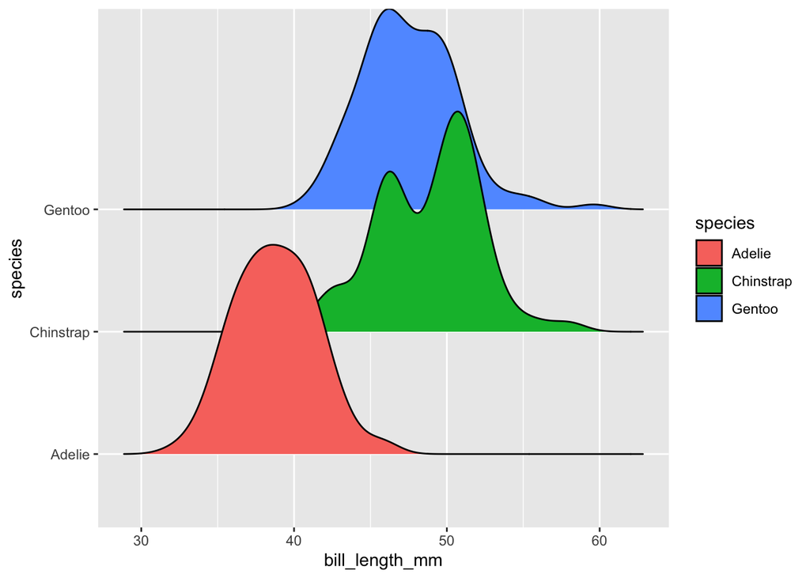

```r
library(ggridges)
ggplot(penguins, aes(x=bill_length_mm, y=species, fill=species)) + geom_density_ridges()
```

What if we want to view two variables at once for example, bill length and bill depth? We can use a scatter plot to view their joint distribution. We can use color and plotting shapes to indicate species and sex.

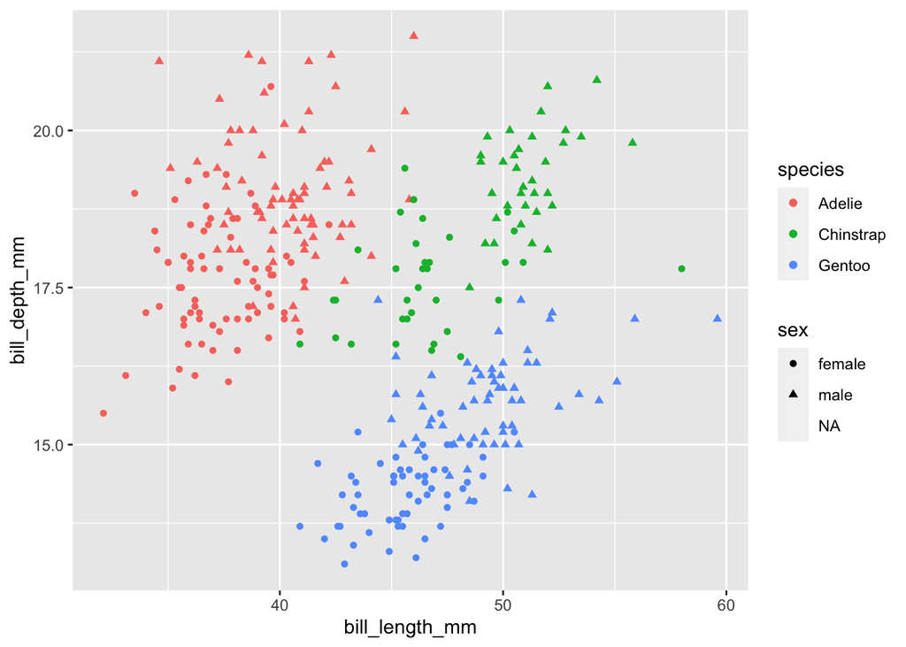

```r
ggplot(penguins, aes(x=bill_length_mm, y=bill_depth_mm, color=species, shape=sex)) + geom_point()
```

# Descriptive statistics

Exercise: Plot the distributions of bill lengths of male and female penguins separately for each species.

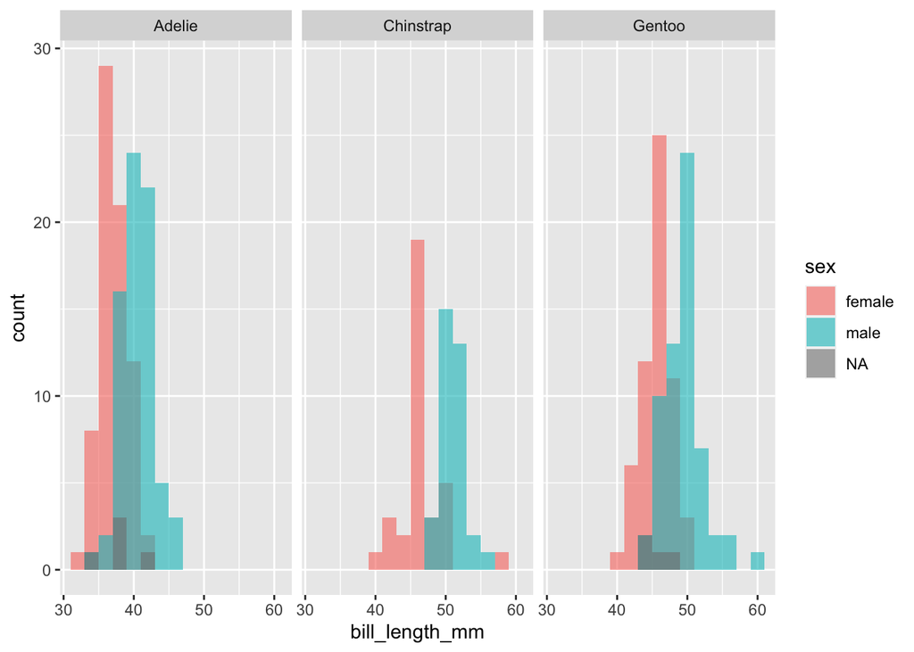

```r
ggplot(penguins, aes(x=bill_length_mm, fill=sex)) + geom_histogram(position="identity", alpha=0.6, binwidth=2) + facet_wrap(.~species)
```

What is are the mean bill lengths for the male chinstrap penguins and female chinstrap penguins